# SAVI case study — STING signature on monocytic reference

# Single-cell expression on UMAP (GEO Seurat object)

Published scRNA-seq object GSE226598 (`prepare_data.R`). We subset **`params$savi_sc_celltype`** (disease-associated monocytes — same population as the pseudobulk merge) and plot signature genes on the embedded UMAP, **`split.by = "Category"`** (`CTRL`, `SAVI`, `SAVI_treated`), using the **`SCT`** assay **`data`** slot (SCTransform–normalized expression from the published object).

```r
read_geo_rds_gz <- function(path) {
  con <- gzcon(gzfile(path))
  on.exit(close(con), add = TRUE)
  readRDS(con)
}

seurat_savi <- read_geo_rds_gz(params$savi_seurat_gz)

if (!"Category" %in% colnames(seurat_savi@meta.data)) {
  stop("`Category` not found in Seurat metadata.")
}

seurat_savi$Category <- factor(
  seurat_savi$Category,
  levels = c("CTRL", "SAVI", "SAVI_treated")
)

seurat_reduction <- function(se) {
  nms <- names(se@reductions)
  hit <- intersect(c("umap", "UMAP", "tsne", "TSNE"), nms)
  if (length(hit)) {
    return(hit[[1]])
  }
  nms[[1]]
}

reduction_use <- seurat_reduction(seurat_savi)

# Subset early so we don't keep the full >2k x 24k object around.
seurat_savi_mono <- seurat_savi |>
  subset(CellType == params$savi_sc_celltype)
# rm(seurat_savi)
# gc(verbose = FALSE)

tibble::tibble(
  n_cells = ncol(seurat_savi_mono),
  reduction = reduction_use,
  categories = paste(levels(seurat_savi_mono$Category), collapse = ", "),
  il1b_present = "IL1B" %in% rownames(seurat_savi_mono),
  adrb2_present = "ADRB2" %in% rownames(seurat_savi_mono)
)
```

| n_cells | reduction | categories | il1b_present | adrb2_present |
| --- | --- | --- | --- | --- |
| 2290 | umap | CTRL, SAVI, SAVI_treated | TRUE | TRUE |

```r
if (ncol(seurat_savi_mono) == 0L) {
  stop(
    "No cells for CellType = '", params$savi_sc_celltype,
    "'. Check `CellType` levels in the Seurat object."
  )
}

seurat_savi_mono$Category <- factor(
  seurat_savi_mono$Category,
  levels = c("CTRL", "SAVI", "SAVI_treated")
)

tibble::tibble(
  cell_type = params$savi_sc_celltype,
  n_cells = ncol(seurat_savi_mono)
)
```

| cell_type | n_cells |
| --- | --- |
| 17. Disease-associated monocytes | 2290 |

```r
table(seurat_savi_mono$Category, useNA = "ifany")
```

```
        CTRL         SAVI SAVI_treated
         344         1528          418
```

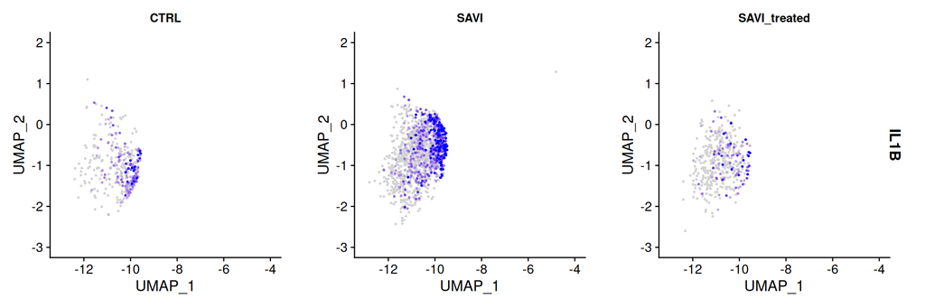

```r
if (!"SCT" %in% SeuratObject::Assays(seurat_savi_mono)) {
  stop(
    "SCT assay not found. Available: ",
    paste(SeuratObject::Assays(seurat_savi_mono), collapse = ", ")
  )
}

if (!"IL1B" %in% rownames(seurat_savi_mono[["SCT"]])) {
  stop("IL1B not found in SCT assay rownames.")
}

Seurat::FeaturePlot(
  seurat_savi_mono,
  features = "IL1B",
  assay = "SCT",
  split.by = "Category",
  reduction = reduction_use,
  slot = "data",
  ncol = 3,
  order = TRUE,
  pt.size = 0.35,
  min.cutoff = "q10",
  max.cutoff = "q90"
) &
  ggplot2::theme(
    plot.title = ggplot2::element_text(size = 11),
    strip.text = ggplot2::element_text(size = 11, face = "bold")
  )
```

Panel titles are **`Category`** (study cohort label from GEO metadata). Expression is from **SCTransform** (`assay = "SCT"`, `slot = "data"`), not raw **`RNA`** counts. High **`IL1B`** in **CTRL** monocytes complements the pseudobulk / atlas falsification checks above.

#### *ADRB2* on UMAP (all donors)

Same layout as *IL1B*: disease-associated monocytes, SCT **`data`**, **`split.by = "Category"`**. Compare the **SAVI** column to **CTRL** and **SAVI_treated** — cells from all donors in each arm are pooled on the UMAP.

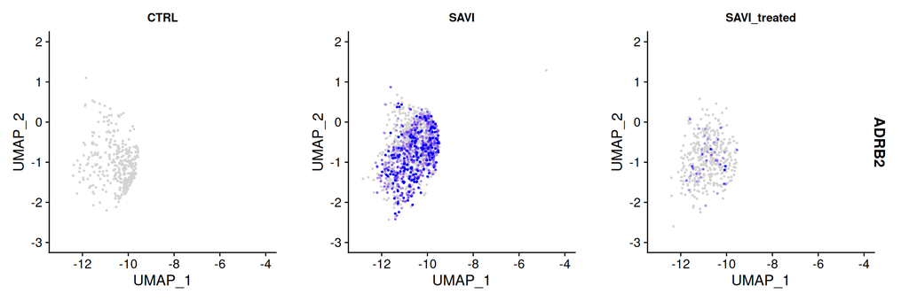

```r
if (!"ADRB2" %in% rownames(seurat_savi_mono[["SCT"]])) {
  stop("ADRB2 not found in SCT assay rownames.")
}

Seurat::FeaturePlot(
  seurat_savi_mono,
  features = "ADRB2",
  assay = "SCT",
  split.by = "Category",
  reduction = reduction_use,
  slot = "data",
  ncol = 3,
  order = TRUE,
  pt.size = 0.35,
  min.cutoff = "q10",
  max.cutoff = "q90"
) &
  ggplot2::theme(
    plot.title = ggplot2::element_text(size = 11),
    strip.text = ggplot2::element_text(size = 11, face = "bold")
  )
```

The **SAVI** panel above pools monocytes from all five untreated SAVI donors. Pseudobulk checks show atlas deviation is dominated by **`P6_STING_ht`** (4057 raw counts, **`p_above_healthy < 0.025`**); the other four SAVI donors sit near the healthy null (≤65 raw counts). If **`ADRB2`** signal in **SAVI** is sparse overall but driven by cells from that donor, the pooled UMAP can still look elevated.

#### *ADRB2* after removing the atlas-tail donor

Mirroring **`plot-adrb2-leave-one-out`** on pseudobulk, we repeat the UMAP with **every disease-associated monocyte from the atlas-tail SAVI donor removed** (`adrb2_savi_outlier$Sample`, here **`P6_STING_ht`**). Assay, cell type, and **`split.by = "Category"`** are unchanged; only that library’s cells are dropped, so the **SAVI** facet reflects the remaining four untreated SAVI donors. If the **SAVI** panel now resembles **CTRL** / **SAVI_treated**, the cohort-level **`ADRB2`** signal is a **one-donor** artefact at single-cell resolution as well as in pseudobulk.

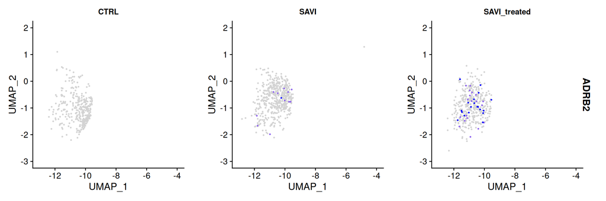

```r
if (!"ADRB2" %in% rownames(seurat_savi_mono[["SCT"]])) {
  stop("ADRB2 not found in SCT assay rownames.")
}

if (!"Sample" %in% colnames(seurat_savi_mono@meta.data)) {
  stop("`Sample` not found in Seurat metadata.")
}

outlier_sample <- adrb2_savi_outlier$Sample

seurat_savi_mono_no_outlier <- subset(
  seurat_savi_mono,
  subset = Sample != outlier_sample
)

Seurat::FeaturePlot(
  seurat_savi_mono_no_outlier,
  features = "ADRB2",
  assay = "SCT",
  split.by = "Category",
  reduction = reduction_use,
  slot = "data",
  ncol = 3,
  order = TRUE,
  pt.size = 0.35,
  min.cutoff = "q10",
  max.cutoff = "q90"
) &
  ggplot2::theme(
    plot.title = ggplot2::element_text(size = 11),
    strip.text = ggplot2::element_text(size = 11, face = "bold")
  )
```

**Read together:** the all-donor and leave-one-out UMAPs ask the same question as the pseudobulk falsification — is **`ADRB2`** elevated across **SAVI**, or only when **`P6_STING_ht`** is included? Concordance between a muted **SAVI** panel after exclusion and the drop in SAVI mean **`log2fc`** in **`plot-adrb2-leave-one-out`** strengthens the **`falsified_no_savi_signal`** classification (20% of SAVI donors pass the strict atlas tail test).

# Composition analysis vs original SAVI paper

In the original SAVI scRNA-seq paper (de Cevins *et al.* 2023; GSE226598), after QC, integration, clustering, and annotation, the authors report **23 cell populations** in the SAVI dataset and **29 cell populations** in the IFN-beta dataset. They then compare PBMC composition between SAVI and controls (Figure 1E), with p-values from Kruskal-Wallis tests followed by post hoc Dunn’s multiple-comparison testing.

For whole-PBMC composition, the paper reports increased naive CD4 and naive CD8 T cells, decreased effector/memory CD4 and CD8 T-cell compartments, decreased NK cells (especially NK CD56bright), and strong depletion of MAIT and gamma-delta T cells in SAVI. They also report that cell-type proportions did not differ significantly before versus under JAK-inhibitor treatment.

In this notebook, we use those statements as the reference conclusion, then:

1. compute per-sample proportions from GEO **`CellType`** (23 populations),
2. map **`CellType` → Immune Atlas `L3`** labels used by the sccomp composition model,
3. compare observed proportions to healthy **`predict_res`** draws matched on **`sex`** and **`age_decade`**,
4. summarise trends in **`CTRL`**, **`SAVI`**, and **`SAVI_treated`** against the paper’s Figure 1E conclusions.

```r
paper_composition_summary <- tibble::tribble(
  ~topic, ~paper_finding,
  "Dataset size after integration", "23 populations (SAVI dataset) and 29 populations (IFN-beta dataset).",
  "Naive T-cell compartments", "Naive CD4 and naive CD8 T-cell proportions are increased in SAVI.",
  "Effector/memory T-cell compartments", "Effector/memory CD4 and CD8 compartments are decreased in SAVI.",
  "Innate-like / cytotoxic compartments", "NK cells (notably NK CD56bright), MAIT cells, and gamma-delta T cells are reduced in SAVI.",
  "Treatment comparison", "No significant composition differences were observed before versus under JAK inhibitor treatment.",
  "Statistics in Figure 1E", "Kruskal-Wallis tests with post hoc Dunn's multiple comparisons."
)

paper_composition_summary
```

| topic | paper_finding |
| --- | --- |
| Dataset size after integration | 23 populations (SAVI dataset) and 29 populations (IFN-beta dataset). |
| Naive T-cell compartments | Naive CD4 and naive CD8 T-cell proportions are increased in SAVI. |
| Effector/memory T-cell compartments | Effector/memory CD4 and CD8 compartments are decreased in SAVI. |
| Innate-like / cytotoxic compartments | NK cells (notably NK CD56bright), MAIT cells, and gamma-delta T cells are reduced in SAVI. |
| Treatment comparison | No significant composition differences were observed before versus under JAK inhibitor treatment. |
| Statistics in Figure 1E | Kruskal-Wallis tests with post hoc Dunn's multiple comparisons. |

```r
paper_ct_alignment <- tibble::tribble(
  ~paper_compartment, ~direction_in_savi, ~celltype_labels_in_this_object, ~mapping_note,
  "Naive CD4 T", "increased", "0. Naive CD4", "Directly aligned.",
  "Effector/memory CD4", "decreased", "3. CM CD4; 4. EM CD4; 8. TE CD4; 9. Tregs and TE CD4", "Approximate effector/memory CD4 pool from available labels.",
  "Naive CD8 T", "increased", "2. Naive CD8", "Directly aligned.",
  "Effector/memory CD8", "decreased", "14. CM CD8; 15. EM CD8; 7. TE CD8", "Approximate effector/memory CD8 pool from available labels.",
  "NK (especially CD56bright)", "decreased", "10. NK; 26. NK CD56bright", "CD56bright is explicitly available.",
  "MAIT", "strongly decreased", "22. MAIT", "Directly aligned.",
  "gamma-delta T", "strongly decreased", "16. gd T cells", "Directly aligned.",
  "Myeloid context (not primary Figure 1E claim)", "context", "5. Classical monocytes; 12. Non-classical monocytes; 17. Disease-associated monocytes; 20. cDCs; 27. pDCs", "Contextual comparison only.",
  "B-cell context (not primary Figure 1E claim)", "context", "1. Naive B; 6. Transitionnal B; 13. Memory B; 11. CD3+ B cells; 25. Plasmablasts", "Contextual comparison only."
)

paper_ct_alignment
```

| paper_compartment | direction_in_savi | celltype_labels_in_this_object | mapping_note |
| --- | --- | --- | --- |
| Naive CD4 T | increased | 0. Naive CD4 | Directly aligned. |
| Effector/memory CD4 | decreased | 3. CM CD4; 4. EM CD4; 8. TE CD4; 9. Tregs and TE CD4 | Approximate effector/memory CD4 pool from available labels. |
| Naive CD8 T | increased | 2. Naive CD8 | Directly aligned. |
| Effector/memory CD8 | decreased | 14. CM CD8; 15. EM CD8; 7. TE CD8 | Approximate effector/memory CD8 pool from available labels. |
| NK (especially CD56bright) | decreased | 10. NK; 26. NK CD56bright | CD56bright is explicitly available. |
| MAIT | strongly decreased | 22. MAIT | Directly aligned. |
| gamma-delta T | strongly decreased | 16. gd T cells | Directly aligned. |
| Myeloid context (not primary Figure 1E claim) | context | 5. Classical monocytes; 12. Non-classical monocytes; 17. Disease-associated monocytes; 20. cDCs; 27. pDCs | Contextual comparison only. |
| B-cell context (not primary Figure 1E claim) | context | 1. Naive B; 6. Transitionnal B; 13. Memory B; 11. CD3+ B cells; 25. Plasmablasts | Contextual comparison only. |

```r
if (!exists("read_geo_rds_gz", mode = "function")) {
  read_geo_rds_gz <- function(path) {
    con <- gzcon(gzfile(path))
    on.exit(close(con), add = TRUE)
    readRDS(con)
  }
}

if (!exists("seurat_savi", inherits = FALSE)) {
  seurat_savi <- read_geo_rds_gz(params$savi_seurat_gz)
}

if (!"Category" %in% colnames(seurat_savi@meta.data)) {
  stop("`Category` not found in Seurat metadata.")
}
if (!"CellType" %in% colnames(seurat_savi@meta.data)) {
  stop("`CellType` not found in Seurat metadata.")
}

seurat_savi$Category <- factor(
  seurat_savi$Category,
  levels = c("CTRL", "SAVI", "SAVI_treated")
)

# GEO sample metadata (same table as pseudobulk join above).
geo_tbl_comp <- geo_tbl |>
  dplyr::mutate(
    sex = dplyr::case_when(
      .data$gse_sex == "M" ~ "male",
      .data$gse_sex == "F" ~ "female",
      TRUE ~ NA_character_
    ),
    age_decade = as.character(ceiling(.data$gse_age_years / 10))
  ) |>
  dplyr::select("Sample", "sex", "age_decade", "gse_age_years")

# Fine-grained CellType -> Immune Atlas L3 (posteriorHCA / sccomp) labels.
celltype_to_l3 <- tibble::tribble(
  ~cell_type, ~L3,
  "0. Naive CD4", "cd4 naive",
  "2. Naive CD8", "cd8 naive",
  "3. CM CD4", "cd4 tcm",
  "4. EM CD4", "cd4 th1 em",
  "8. TE CD4", "cd4 th1 em",
  "9. Tregs and TE CD4", "treg",
  "14. CM CD8", "cd8 tcm",
  "15. EM CD8", "cd8 tem",
  "7. TE CD8", "cd8 tem",
  "10. NK", "nk",
  "26. NK CD56bright", "nk",
  "22. MAIT", "mait",
  "16. gd T cells", "tgd",
  "1. Naive B", "b naive",
  "6. Transitionnal B", "b naive",
  "13. Memory B", "b memory",
  "11. CD3+ B cells", "b memory",
  "5. Classical monocytes", "cd14 mono",
  "12. Non-classical monocytes", "cd16 mono",
  "17. Disease-associated monocytes", "cd14 mono",
  "20. cDCs", "cdc",
  "27. pDCs", "pdc",
  "25. Plasmablasts", "plasma"
)

cell_tbl <- seurat_savi@meta.data |>
  tibble::rownames_to_column("cell_id") |>
  dplyr::transmute(
    sample_id = as.character(.data$Sample),
    Category = as.character(.data$Category),
    cell_type = as.character(.data$CellType)
  ) |>
  dplyr::left_join(celltype_to_l3, by = "cell_type") |>
  dplyr::left_join(geo_tbl_comp, by = c("sample_id" = "Sample"))

example_proportions_celltype <- cell_tbl |>
  dplyr::filter(!is.na(.data$cell_type), nzchar(.data$cell_type)) |>
  dplyr::count(.data$sample_id, .data$cell_type, name = "n_cells") |>
  dplyr::group_by(.data$sample_id) |>
  dplyr::mutate(proportion = .data$n_cells / sum(.data$n_cells)) |>
  dplyr::ungroup() |>
  dplyr::select(.data$sample_id, .data$cell_type, .data$proportion)

# L3-level observed proportions (merge CellType labels that map to the same L3).
example_proportions <- cell_tbl |>
  dplyr::filter(!is.na(.data$L3)) |>
  dplyr::count(.data$sample_id, .data$Category, .data$sex, .data$age_decade, .data$L3, name = "n_cells") |>
  dplyr::group_by(.data$sample_id, .data$Category, .data$sex, .data$age_decade, .data$L3) |>
  dplyr::summarise(proportion = sum(.data$n_cells), .groups = "drop_last") |>
  dplyr::group_by(.data$sample_id) |>
  dplyr::mutate(proportion = .data$proportion / sum(.data$proportion)) |>
  dplyr::ungroup() |>
  dplyr::rename(cell_type = L3) |>
  dplyr::arrange(.data$sample_id, .data$cell_type)

unmapped_celltypes <- cell_tbl |>
  dplyr::filter(is.na(.data$L3)) |>
  dplyr::count(.data$cell_type, sort = TRUE)

tibble::tibble(
  label_column_used = "CellType",
  n_samples = dplyr::n_distinct(example_proportions$sample_id),
  n_cells_total = nrow(cell_tbl),
  n_celltypes_raw = dplyr::n_distinct(example_proportions_celltype$cell_type),
  n_l3_types = dplyr::n_distinct(example_proportions$cell_type),
  n_unmapped_celltypes = nrow(unmapped_celltypes)
)
```

| label_column_used | n_samples | n_cells_total | n_celltypes_raw | n_l3_types | n_unmapped_celltypes |
| --- | --- | --- | --- | --- | --- |
| CellType | 17 | 112060 | 23 | 17 | 0 |

```r
if (nrow(unmapped_celltypes) > 0L) {
  unmapped_celltypes
}
```

### Healthy atlas composition null (`predict_res`)

Posterior draws of blood PBMC composition from the Immune Atlas sccomp model (`disease_groups___altered = Normal`), stratified by **`sex`** (`male` / `female`) and **`age_decade`** (`1`–`4`), matching SAVI donor metadata. The draw table is **not** knitr-cached (too large for R’s cache serializer); it is saved once to **`params$composition_predict_rds`** and trimmed to L3 types present in the SAVI cohort.

```r
if (!requireNamespace("sccomp", quietly = TRUE)) {
  stop("Package `sccomp` is required for composition prediction.")
}

l3_for_comparison <- example_proportions |>
  dplyr::distinct(.data$cell_type) |>
  dplyr::pull(.data$cell_type)

trim_predict_res <- function(x, cell_types) {
  x |>
    dplyr::filter(.data$cell_type %in% cell_types) |>
    dplyr::select(dplyr::any_of(c(
      "sample_id",
      "age_decade",
      "sex",
      "cell_type",
      "proportion",
      ".draw"
    )))
}

if (file.exists(params$composition_predict_rds)) {
  predict_res <- readRDS(params$composition_predict_rds)
} else {
  sccomp_est <- readRDS(params$sccomp_estimates_rds)

  sample_metadata <- tidyr::expand_grid(
    age_decade = as.character(1:4),
    sex = c("male", "female")
  ) |>
    dplyr::mutate(
      assay_groups___altered = "10x Genomics 3",
      disease_groups___altered = "Normal",
      tissue_groups = "blood",
      ethnicity_groups_imputed = NA,
      dataset_id___altered = NA,
      sample_id = paste0("S", dplyr::row_number())
    )

  predict_res <- sccomp_est |>
    sccomp::sccomp_predict(
      formula_composition = NULL,
      new_data = sample_metadata,
      summary_instead_of_draws = FALSE
    ) |>
    dplyr::rename(cell_type = L3) |>
    trim_predict_res(l3_for_comparison)

  predict_dir <- dirname(params$composition_predict_rds)
  if (!dir.exists(predict_dir)) {
    dir.create(predict_dir, recursive = TRUE, showWarnings = FALSE)
  }
  saveRDS(predict_res, params$composition_predict_rds, compress = "xz")
}
```

```
Running standalone generated quantities after 1 MCMC chain, with 1 thread(s) per chain...

Chain 1  Elapsed Time: 4.251 seconds (Generated Quantities)
Chain 1 finished in 0.0 seconds.
```

```r
predict_res <- trim_predict_res(predict_res, l3_for_comparison)

predict_res |>
  dplyr::distinct(.data$age_decade, .data$sex, .data$cell_type) |>
  dplyr::count(.data$age_decade, .data$sex, name = "n_cell_types")
```

| age_decade | sex | n_cell_types |
| --- | --- | --- |
| 1 | female | 17 |
| 1 | male | 17 |
| 2 | female | 17 |
| 2 | male | 17 |
| 3 | female | 17 |
| 3 | male | 17 |
| 4 | female | 17 |
| 4 | male | 17 |

### Compare observed SAVI proportions to healthy predictive draws

For each donor we match **`predict_res`** rows with the same **`sex`** and **`age_decade`**, then compute empirical tail probabilities (same logic as `posteriorHCA::composition_posterior_test()`).

```r
composition_vs_healthy <- example_proportions |>
  dplyr::rename(
    sample_id_observed = sample_id,
    cell_type_observed = cell_type,
    proportion_observed = proportion
  ) |>
  dplyr::inner_join(
    predict_res |>
      dplyr::select(
        age_decade, sex, cell_type, proportion_sampled = proportion, .draw
      ),
    by = c("sex" = "sex", "age_decade" = "age_decade", "cell_type_observed" = "cell_type"),
    relationship = "many-to-many"
  ) |>
  dplyr::group_by(.data$sample_id_observed, .data$Category, .data$cell_type_observed) |>
  dplyr::summarise(
    proportion_observed = dplyr::first(.data$proportion_observed),
    healthy_median = stats::median(.data$proportion_sampled),
    healthy_mean = mean(.data$proportion_sampled),
    healthy_hpd_lo = stats::quantile(.data$proportion_sampled, 0.025),
    healthy_hpd_hi = stats::quantile(.data$proportion_sampled, 0.975),
    # Same tail convention as `gene_deviation_from_fit()`: P(draw >= obs), not P(obs > draw).
    p_above_healthy = mean(.data$proportion_sampled >= .data$proportion_observed),
    p_below_healthy = mean(.data$proportion_sampled <= .data$proportion_observed),
    empirical_confidence = 2 * pmin(.data$p_above_healthy, .data$p_below_healthy),
    direction = dplyr::case_when(
      .data$p_above_healthy < 0.025 ~ "higher_than_healthy",
      .data$p_below_healthy < 0.025 ~ "lower_than_healthy",
      TRUE ~ "consistent_with_healthy"
    ),
    .groups = "drop"
  )

composition_vs_healthy |>
  dplyr::arrange(.data$Category, .data$cell_type_observed, .data$sample_id_observed) |>
  dplyr::slice_head(n = 12)
```

| sample_id_observed | Category | cell_type_observed | proportion_observed | healthy_median | healthy_mean | healthy_hpd_lo | healthy_hpd_hi | p_above_healthy | p_below_healthy | empirical_confidence | direction |
| --- | --- | --- | --- | --- | --- | --- | --- | --- | --- | --- | --- |
| C1 | CTRL | b memory | 0.03109734 | 0.031279862 | 0.032452778 | 0.019276248 | 0.049817234 | 0.512 | 0.488 | 0.976 | consistent_with_healthy |
| C10 | CTRL | b memory | 0.02790052 | 0.031069452 | 0.031091028 | 0.024345801 | 0.037826713 | 0.808 | 0.192 | 0.384 | consistent_with_healthy |
| C11 | CTRL | b memory | 0.02373307 | 0.100572835 | 0.134951628 | 0.015936391 | 0.420928358 | 0.934 | 0.066 | 0.132 | consistent_with_healthy |
| C2 | CTRL | b memory | 0.06764499 | 0.031279862 | 0.032452778 | 0.019276248 | 0.049817234 | 0.000 | 1.000 | 0.000 | higher_than_healthy |
| C7 | CTRL | b memory | 0.10581456 | 0.019449594 | 0.019767321 | 0.011083131 | 0.032490878 | 0.000 | 1.000 | 0.000 | higher_than_healthy |
| C8_aunt_P1_STING | CTRL | b memory | 0.03123687 | 0.056496240 | 0.056537856 | 0.048566616 | 0.064933963 | 1.000 | 0.000 | 0.000 | lower_than_healthy |
| C9_mother_P1_STING | CTRL | b memory | 0.03290415 | 0.056496240 | 0.056537856 | 0.048566616 | 0.064933963 | 1.000 | 0.000 | 0.000 | lower_than_healthy |
| C1 | CTRL | b naive | 0.07172644 | 0.029999957 | 0.031078939 | 0.018224404 | 0.049377462 | 0.000 | 1.000 | 0.000 | higher_than_healthy |
| C10 | CTRL | b naive | 0.10289105 | 0.006463431 | 0.006466794 | 0.004566616 | 0.008468927 | 0.000 | 1.000 | 0.000 | higher_than_healthy |
| C11 | CTRL | b naive | 0.07441016 | 0.095475736 | 0.125167592 | 0.014938011 | 0.407876319 | 0.570 | 0.430 | 0.860 | consistent_with_healthy |

[output cut: 2 more lines]

### Paper compartments: trend by `Category` and comparison to published direction

```r
paper_compartment_l3 <- tibble::tribble(
  ~paper_compartment, ~direction_in_savi, ~cell_type,
  "Naive CD4 T", "increased", "cd4 naive",
  "Effector/memory CD4", "decreased", "cd4 tcm",
  "Effector/memory CD4", "decreased", "cd4 th1 em",
  "Effector/memory CD4", "decreased", "cd4 th17 em",
  "Effector/memory CD4", "decreased", "cd4 th2 em",
  "Effector/memory CD4", "decreased", "cd4 fh em",
  "Effector/memory CD4", "decreased", "cd4 th1/th17 em",
  "Effector/memory CD4", "decreased", "treg",
  "Naive CD8 T", "increased", "cd8 naive",
  "Effector/memory CD8", "decreased", "cd8 tcm",
  "Effector/memory CD8", "decreased", "cd8 tem",
  "NK", "decreased", "nk",
  "MAIT", "strongly decreased", "mait",
  "gamma-delta T", "strongly decreased", "tgd"
)

composition_paper_per_donor <- composition_vs_healthy |>
  dplyr::inner_join(paper_compartment_l3, by = c("cell_type_observed" = "cell_type")) |>
  dplyr::group_by(
    .data$sample_id_observed,
    .data$Category,
    .data$paper_compartment,
    .data$direction_in_savi
  ) |>
  dplyr::summarise(
    proportion_observed = sum(.data$proportion_observed),
    healthy_median = sum(.data$healthy_median),
    direction = dplyr::if_else(
      any(.data$direction == "higher_than_healthy"),
      "higher_than_healthy",
      dplyr::if_else(
        any(.data$direction == "lower_than_healthy"),
        "lower_than_healthy",
        "consistent_with_healthy"
      )
    ),
    .groups = "drop"
  )

# Donors with zero cells in a compartment are absent from counts; fill with 0 so
# category means (and CTRL dots) include all donors in each Category.
all_donors_comp <- example_proportions |>
  dplyr::distinct(.data$sample_id, .data$Category) |>
  dplyr::rename(sample_id_observed = sample_id)

compartment_meta <- paper_compartment_l3 |>
  dplyr::distinct(.data$paper_compartment, .data$direction_in_savi)

composition_paper_long <- tidyr::crossing(all_donors_comp, compartment_meta) |>
  dplyr::left_join(
    composition_paper_per_donor,
    by = c("sample_id_observed", "Category", "paper_compartment", "direction_in_savi")
  ) |>
  dplyr::mutate(
    proportion_observed = dplyr::coalesce(.data$proportion_observed, 0),
    healthy_median = dplyr::coalesce(.data$healthy_median, 0),
    direction = dplyr::coalesce(.data$direction, "consistent_with_healthy")
  )

composition_paper_summary <- composition_paper_long |>
  dplyr::group_by(.data$paper_compartment, .data$direction_in_savi, .data$Category) |>
  dplyr::summarise(
    n_samples = dplyr::n(),
    mean_prop = mean(.data$proportion_observed),
    median_prop = stats::median(.data$proportion_observed),
    mean_healthy_median = mean(.data$healthy_median),
    .groups = "drop"
  ) |>
  tidyr::pivot_wider(
    names_from = Category,
    values_from = c(mean_prop, median_prop, n_samples),
    names_sep = "__"
  ) |>
  dplyr::mutate(
    delta_savi_minus_ctrl = .data$mean_prop__SAVI - .data$mean_prop__CTRL,
    delta_treated_minus_ctrl = .data$mean_prop__SAVI_treated - .data$mean_prop__CTRL,
    matches_paper_savi = dplyr::case_when(
      .data$direction_in_savi == "increased" ~ .data$delta_savi_minus_ctrl > 0,
      .data$direction_in_savi %in% c("decreased", "strongly decreased") ~ .data$delta_savi_minus_ctrl < 0,
      TRUE ~ NA
    ),
    matches_paper_treated = dplyr::case_when(
      .data$direction_in_savi == "increased" ~ .data$delta_treated_minus_ctrl > 0,
      .data$direction_in_savi %in% c("decreased", "strongly decreased") ~ .data$delta_treated_minus_ctrl < 0,
      TRUE ~ NA
    )
  ) |>
  dplyr::arrange(.data$paper_compartment)

composition_paper_summary
```

| paper_compartment | direction_in_savi | mean_healthy_median | mean_prop__CTRL | mean_prop__SAVI | mean_prop__SAVI_treated | median_prop__CTRL | median_prop__SAVI | median_prop__SAVI_treated | n_samples__CTRL | n_samples__SAVI | n_samples__SAVI_treated | delta_savi_minus_ctrl | delta_treated_minus_ctrl | matches_paper_savi | matches_paper_treated |
| --- | --- | --- | --- | --- | --- | --- | --- | --- | --- | --- | --- | --- | --- | --- | --- |
| Effector/memory CD4 | decreased | 0.088120122 | 0.27312712 | NA | NA | 0.23690823 | NA | NA | 7 | NA | NA | NA | NA | NA | NA |
| Effector/memory CD4 | decreased | 0.036593709 | NA | 0.2178529260 | NA | NA | 0.1791621580 | NA | NA | 5 | NA | NA | NA | NA | NA |
| Effector/memory CD4 | decreased | 0.056720568 | NA | NA | 0.1714490033 | NA | NA | 0.1642066421 | NA | NA | 5 | NA | NA | NA | NA |
| Effector/memory CD8 | decreased | 0.095664828 | 0.13104561 | NA | NA | 0.13304481 | NA | NA | 7 | NA | NA | NA | NA | NA | NA |
| Effector/memory CD8 | decreased | 0.070491790 | NA | 0.0547403692 | NA | NA | 0.0624145786 | NA | NA | 5 | NA | NA | NA | NA | NA |
| Effector/memory CD8 | decreased | 0.091788627 | NA | NA | 0.0574797344 | NA | NA | 0.0430379747 | NA | NA | 5 | NA | NA | NA | NA |
| MAIT | strongly decreased | 0.010103971 | 0.01746032 | NA | NA | 0.01431814 | NA | NA | 7 | NA | NA | NA | NA | NA | NA |
| MAIT | strongly decreased | 0.005592229 | NA | 0.0008085549 | NA | NA | 0.0002074474 | NA | NA | 5 | NA | NA | NA | NA | NA |
| MAIT | strongly decreased | 0.003967063 | NA | NA | 0.0002977762 | NA | NA | 0.0002462751 | NA | NA | 5 | NA | NA | NA | NA |
| NK | decreased | 0.155774755 | 0.05431243 | NA | NA | 0.04456094 | NA | NA | 7 | NA | NA | NA | NA | NA | NA |

[output cut: 11 more lines]

### Healthy baseline vs age decade

Healthy atlas predictive draws (`predict_res`, Normal blood): for each **paper compartment**, sum mapped L3 proportions per draw, then summarise by **`sex`** and **`age_decade`** (1–4).

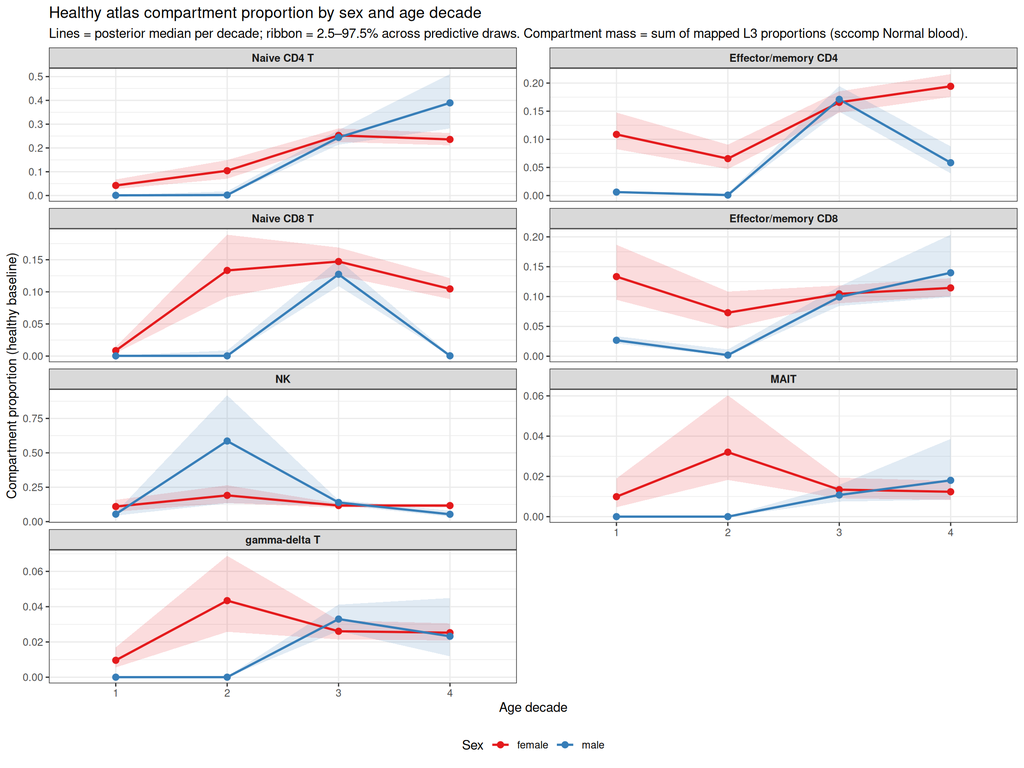

```r
healthy_baseline_compartment_age <- predict_res |>
  dplyr::inner_join(
    paper_compartment_l3 |>
      dplyr::distinct(.data$paper_compartment, .data$cell_type),
    by = "cell_type"
  ) |>
  dplyr::group_by(
    .data$paper_compartment,
    .data$sex,
    .data$age_decade,
    .data$.draw
  ) |>
  dplyr::summarise(
    compartment_proportion = sum(.data$proportion),
    .groups = "drop"
  ) |>
  dplyr::group_by(
    .data$paper_compartment,
    .data$sex,
    .data$age_decade
  ) |>
  dplyr::summarise(
    median_proportion = stats::median(.data$compartment_proportion),
    hpd_lo = stats::quantile(.data$compartment_proportion, 0.025),
    hpd_hi = stats::quantile(.data$compartment_proportion, 0.975),
    .groups = "drop"
  ) |>
  dplyr::mutate(
    age_decade = factor(.data$age_decade, levels = as.character(1:4)),
    sex = factor(.data$sex, levels = c("female", "male")),
    paper_compartment = factor(
      .data$paper_compartment,
      levels = unique(paper_compartment_l3$paper_compartment)
    )
  )

sex_cols <- c(female = "#E41A1C", male = "#377EB8")

ggplot2::ggplot(
  healthy_baseline_compartment_age,
  ggplot2::aes(
    x = age_decade,
    y = median_proportion,
    color = sex,
    group = sex
  )
) +
  ggplot2::geom_ribbon(
    ggplot2::aes(ymin = hpd_lo, ymax = hpd_hi, fill = sex),
    alpha = 0.15,
    color = NA
  ) +
  ggplot2::geom_line(linewidth = 0.9) +
  ggplot2::geom_point(size = 2.2) +
  ggplot2::facet_wrap(~paper_compartment, scales = "free_y", ncol = 2) +
  ggplot2::scale_color_manual(values = sex_cols, name = "Sex") +
  ggplot2::scale_fill_manual(values = sex_cols, guide = "none") +
  ggplot2::labs(
    title = "Healthy atlas compartment proportion by sex and age decade",
    subtitle = paste(
      "Lines = posterior median per decade; ribbon = 2.5–97.5% across predictive draws.",
      "Compartment mass = sum of mapped L3 proportions (sccomp Normal blood)."
    ),
    x = "Age decade",
    y = "Compartment proportion (healthy baseline)"
  ) +
  ggplot2::theme_bw() +
  ggplot2::theme(
    legend.position = "bottom",
    strip.text = ggplot2::element_text(face = "bold", size = 9)
  )
```

### Observed composition (within cohort)

Boxplot and bar chart use **observed** compartment proportions only (CTRL / SAVI / SAVI_treated); no healthy atlas reference.

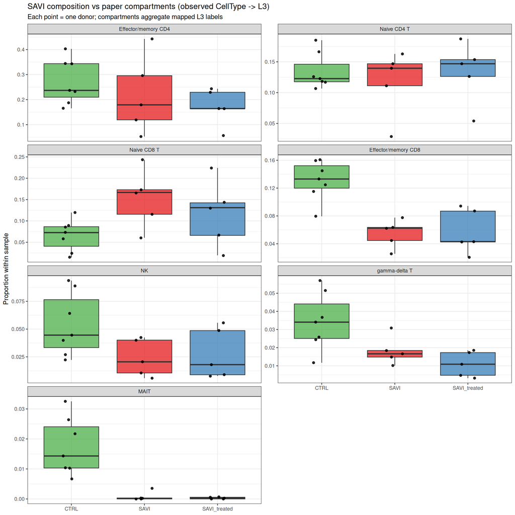

```r
category_cols <- c(
  CTRL = "#4DAF4A",
  SAVI = "#E41A1C",
  SAVI_treated = "#377EB8"
)

plot_data <- composition_paper_long |>
  dplyr::mutate(
    Category = factor(.data$Category, levels = names(category_cols)),
    paper_compartment = forcats::fct_reorder(
      .data$paper_compartment,
      .data$proportion_observed,
      .fun = median,
      .desc = TRUE
    )
  )

ggplot2::ggplot(
  plot_data,
  ggplot2::aes(
    x = Category,
    y = proportion_observed,
    fill = Category
  )
) +
  ggplot2::geom_boxplot(outlier.shape = NA, alpha = 0.75) +
  ggplot2::geom_jitter(width = 0.12, size = 1.6, alpha = 0.85) +
  ggplot2::facet_wrap(~paper_compartment, scales = "free_y", ncol = 2) +
  ggplot2::scale_fill_manual(values = category_cols) +
  ggplot2::labs(
    title = "SAVI composition vs paper compartments (observed CellType -> L3)",
    subtitle = "Each point = one donor; compartments aggregate mapped L3 labels",
    x = NULL,
    y = "Proportion within sample"
  ) +
  ggplot2::theme_bw() +
  ggplot2::theme(legend.position = "none")
```

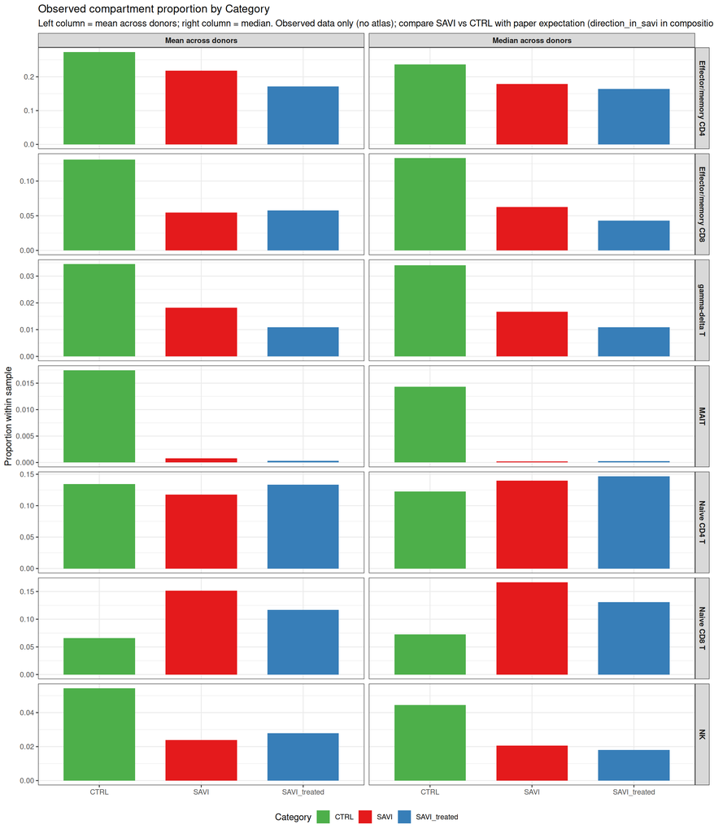

```r
composition_paper_bar <- composition_paper_summary |>
  tidyr::pivot_longer(
    cols = c(
      tidyselect::starts_with("mean_prop__"),
      tidyselect::starts_with("median_prop__")
    ),
    names_to = c("statistic", "Category"),
    names_sep = "__",
    values_to = "prop"
  ) |>
  dplyr::mutate(
    statistic = dplyr::recode(
      .data$statistic,
      mean_prop = "Mean across donors",
      median_prop = "Median across donors"
    ),
    statistic = factor(
      .data$statistic,
      levels = c("Mean across donors", "Median across donors")
    ),
    Category = factor(.data$Category, levels = names(category_cols))
  )

ggplot2::ggplot(
  composition_paper_bar,
  ggplot2::aes(x = Category, y = prop, fill = Category)
) +
  ggplot2::geom_col(position = ggplot2::position_dodge(width = 0.8), width = 0.7) +
  ggplot2::facet_grid(
    paper_compartment ~ statistic,
    scales = "free_y"
  ) +
  ggplot2::scale_fill_manual(values = category_cols) +
  ggplot2::labs(
    title = "Observed compartment proportion by Category",
    subtitle = paste(
      "Left column = mean across donors; right column = median.",
      "Observed data only (no atlas); compare SAVI vs CTRL with paper expectation",
      "(direction_in_savi in composition_paper_summary)."
    ),
    x = NULL,
    y = "Proportion within sample"
  ) +
  ggplot2::theme_bw() +
  ggplot2::theme(
    legend.position = "bottom",
    strip.text = ggplot2::element_text(size = 9, face = "bold")
  )
```

### SAVI donors vs healthy baseline (unified compartments)

For **`SAVI`** and **`SAVI_treated`** donors only, we compare each donor’s **compartment proportion** (sum of mapped L3 types) to healthy **`predict_res`** draws matched on **`sex`** and **`age_decade`**. We then ask whether the atlas tail call (`higher` / `lower` / `consistent` vs healthy) agrees with the **paper’s expected direction** in SAVI (increased vs decreased).

```r
baseline_compartment_draws <- predict_res |>
  dplyr::inner_join(
    paper_compartment_l3 |>
      dplyr::distinct(.data$paper_compartment, .data$cell_type),
    by = "cell_type"
  ) |>
  dplyr::group_by(
    .data$age_decade,
    .data$sex,
    .data$paper_compartment,
    .data$.draw
  ) |>
  dplyr::summarise(
    compartment_proportion = sum(.data$proportion),
    .groups = "drop"
  )

donor_sex_age_all <- example_proportions |>
  dplyr::distinct(.data$sample_id, .data$sex, .data$age_decade) |>
  dplyr::rename(sample_id_observed = sample_id)

# One reference table for all donors: tail test vs sex/age-matched healthy draws.
composition_matched_reference <- composition_paper_long |>
  dplyr::left_join(donor_sex_age_all, by = "sample_id_observed") |>
  dplyr::inner_join(
    baseline_compartment_draws,
    by = c("sex", "age_decade", "paper_compartment"),
    relationship = "many-to-many"
  ) |>
  dplyr::group_by(
    .data$sample_id_observed,
    .data$Category,
    .data$sex,
    .data$age_decade,
    .data$paper_compartment,
    .data$direction_in_savi,
    .data$proportion_observed
  ) |>
  dplyr::summarise(
    healthy_median = stats::median(.data$compartment_proportion),
    healthy_hpd_lo = stats::quantile(.data$compartment_proportion, 0.025),
    healthy_hpd_hi = stats::quantile(.data$compartment_proportion, 0.975),
    p_above_healthy = mean(.data$compartment_proportion >= .data$proportion_observed),
    p_below_healthy = mean(.data$compartment_proportion <= .data$proportion_observed),
    empirical_confidence = 2 * pmin(.data$p_above_healthy, .data$p_below_healthy),
    direction_vs_healthy = dplyr::case_when(
      .data$p_above_healthy < 0.025 ~ "higher_than_healthy",
      .data$p_below_healthy < 0.025 ~ "lower_than_healthy",
      TRUE ~ "consistent_with_healthy"
    ),
    .groups = "drop"
  )

composition_savi_vs_healthy <- composition_matched_reference |>
  dplyr::filter(.data$Category %in% c("SAVI", "SAVI_treated")) |>
  dplyr::mutate(
    atlas_direction_simple = dplyr::case_when(
      .data$direction_vs_healthy == "higher_than_healthy" ~ "increased",
      .data$direction_vs_healthy == "lower_than_healthy" ~ "decreased",
      TRUE ~ "consistent"
    ),
    agrees_with_paper = dplyr::case_when(
      .data$direction_in_savi == "increased" ~
        .data$atlas_direction_simple == "increased",
      .data$direction_in_savi %in% c("decreased", "strongly decreased") ~
        .data$atlas_direction_simple == "decreased",
      TRUE ~ NA
    ),
    agreement_label = dplyr::case_when(
      .data$agrees_with_paper %in% TRUE ~ "agrees (atlas vs paper)",
      .data$agrees_with_paper %in% FALSE ~ "disagrees (atlas vs paper)",
      TRUE ~ "atlas consistent (no tail)"
    )
  )

composition_savi_vs_healthy |>
  dplyr::arrange(.data$Category, .data$paper_compartment, .data$sample_id_observed)
```

| sample_id_observed | Category | sex | age_decade | paper_compartment | direction_in_savi | proportion_observed | healthy_median | healthy_hpd_lo | healthy_hpd_hi | p_above_healthy | p_below_healthy | empirical_confidence | direction_vs_healthy | atlas_direction_simple | agrees_with_paper | agreement_label |
| --- | --- | --- | --- | --- | --- | --- | --- | --- | --- | --- | --- | --- | --- | --- | --- | --- |
| P1_STING_ht | SAVI | female | 1 | Effector/memory CD4 | decreased | 0.2958199357 | 1.087376e-01 | 8.249883e-02 | 1.476310e-01 | 0.000 | 1.000 | 0.000 | higher_than_healthy | increased | FALSE | disagrees (atlas vs paper) |
| P2_STING_ht | SAVI | male | 4 | Effector/memory CD4 | decreased | 0.4426195426 | 5.841655e-02 | 3.955849e-02 | 8.743663e-02 | 0.000 | 1.000 | 0.000 | higher_than_healthy | increased | FALSE | disagrees (atlas vs paper) |
| P4_STING_ht | SAVI | male | 1 | Effector/memory CD4 | decreased | 0.1791621580 | 6.177921e-03 | 4.658945e-03 | 8.081200e-03 | 0.000 | 1.000 | 0.000 | higher_than_healthy | increased | FALSE | disagrees (atlas vs paper) |
| P5_STING | SAVI | male | 1 | Effector/memory CD4 | decreased | 0.1191343964 | 6.177921e-03 | 4.658945e-03 | 8.081200e-03 | 0.000 | 1.000 | 0.000 | higher_than_healthy | increased | FALSE | disagrees (atlas vs paper) |
| P6_STING_ht | SAVI | male | 1 | Effector/memory CD4 | decreased | 0.0525285972 | 6.177921e-03 | 4.658945e-03 | 8.081200e-03 | 0.000 | 1.000 | 0.000 | higher_than_healthy | increased | FALSE | disagrees (atlas vs paper) |
| P1_STING_ht | SAVI | female | 1 | Effector/memory CD8 | decreased | 0.0634788922 | 1.333879e-01 | 9.453058e-02 | 1.866914e-01 | 1.000 | 0.000 | 0.000 | lower_than_healthy | decreased | TRUE | agrees (atlas vs paper) |
| P2_STING_ht | SAVI | male | 4 | Effector/memory CD8 | decreased | 0.0775467775 | 1.398108e-01 | 9.911976e-02 | 2.035350e-01 | 1.000 | 0.000 | 0.000 | lower_than_healthy | decreased | TRUE | agrees (atlas vs paper) |
| P4_STING_ht | SAVI | male | 1 | Effector/memory CD8 | decreased | 0.0446746019 | 2.670789e-02 | 2.127597e-02 | 3.358212e-02 | 0.000 | 1.000 | 0.000 | higher_than_healthy | increased | FALSE | disagrees (atlas vs paper) |
| P5_STING | SAVI | male | 1 | Effector/memory CD8 | decreased | 0.0624145786 | 2.670789e-02 | 2.127597e-02 | 3.358212e-02 | 0.000 | 1.000 | 0.000 | higher_than_healthy | increased | FALSE | disagrees (atlas vs paper) |
| P6_STING_ht | SAVI | male | 1 | Effector/memory CD8 | decreased | 0.0255869958 | 2.670789e-02 | 2.127597e-02 | 3.358212e-02 | 0.638 | 0.362 | 0.724 | consistent_with_healthy | consistent | FALSE | disagrees (atlas vs paper) |

[output cut: 60 more lines]

```r
composition_savi_agreement_summary <- composition_savi_vs_healthy |>
  dplyr::group_by(.data$Category, .data$paper_compartment, .data$direction_in_savi) |>
  dplyr::summarise(
    n_donors = dplyr::n(),
    n_higher = sum(.data$direction_vs_healthy == "higher_than_healthy"),
    n_lower = sum(.data$direction_vs_healthy == "lower_than_healthy"),
    n_consistent = sum(.data$direction_vs_healthy == "consistent_with_healthy"),
    n_agrees_paper = sum(.data$agrees_with_paper %in% TRUE, na.rm = TRUE),
    n_disagrees_paper = sum(.data$agrees_with_paper %in% FALSE, na.rm = TRUE),
    n_testable = sum(!is.na(.data$agrees_with_paper)),
    pct_agrees_paper = dplyr::if_else(
      sum(!is.na(.data$agrees_with_paper)) > 0L,
      100 * mean(.data$agrees_with_paper, na.rm = TRUE),
      NA_real_
    ),
    .groups = "drop"
  ) |>
  dplyr::arrange(.data$Category, .data$paper_compartment)

composition_savi_agreement_summary
```

| Category | paper_compartment | direction_in_savi | n_donors | n_higher | n_lower | n_consistent | n_agrees_paper | n_disagrees_paper | n_testable | pct_agrees_paper |
| --- | --- | --- | --- | --- | --- | --- | --- | --- | --- | --- |
| SAVI | Effector/memory CD4 | decreased | 5 | 5 | 0 | 0 | 0 | 5 | 5 | 0 |
| SAVI | Effector/memory CD8 | decreased | 5 | 2 | 2 | 1 | 2 | 3 | 5 | 40 |
| SAVI | MAIT | strongly decreased | 5 | 1 | 4 | 0 | 4 | 1 | 5 | 80 |
| SAVI | NK | decreased | 5 | 0 | 5 | 0 | 5 | 0 | 5 | 100 |
| SAVI | Naive CD4 T | increased | 5 | 4 | 1 | 0 | 4 | 1 | 5 | 80 |
| SAVI | Naive CD8 T | increased | 5 | 5 | 0 | 0 | 5 | 0 | 5 | 100 |
| SAVI | gamma-delta T | strongly decreased | 5 | 3 | 0 | 2 | 0 | 5 | 5 | 0 |
| SAVI_treated | Effector/memory CD4 | decreased | 5 | 4 | 0 | 1 | 0 | 5 | 5 | 0 |
| SAVI_treated | Effector/memory CD8 | decreased | 5 | 1 | 3 | 1 | 3 | 2 | 5 | 60 |
| SAVI_treated | MAIT | strongly decreased | 5 | 1 | 4 | 0 | 4 | 1 | 5 | 80 |

[output cut: 4 more lines]

```r
# Diagnostic: heatmap tail call vs observed relative to matched healthy median.
composition_naive_cd4_check <- composition_matched_reference |>
  dplyr::filter(
    .data$paper_compartment == "Naive CD4 T",
    .data$Category == "SAVI"
  ) |>
  dplyr::transmute(
    sample_id_observed,
    age_decade,
    sex,
    proportion_observed,
    healthy_median_matched = .data$healthy_median,
    delta_obs_minus_matched = .data$proportion_observed - .data$healthy_median,
    direction_vs_healthy,
    visual_check = dplyr::case_when(
      .data$direction_vs_healthy == "higher_than_healthy" ~
        "solid line should be RIGHT of dashed median",
      .data$direction_vs_healthy == "lower_than_healthy" ~
        "solid line should be LEFT of dashed median",
      TRUE ~ "solid line near dashed median"
    )
  )

composition_naive_cd4_check
```

| sample_id_observed | age_decade | sex | proportion_observed | healthy_median_matched | delta_obs_minus_matched | direction_vs_healthy | visual_check |
| --- | --- | --- | --- | --- | --- | --- | --- |
| P1_STING_ht | 1 | female | 0.14687273 | 0.0423148360 | 0.10455790 | higher_than_healthy | solid line should be RIGHT of dashed median |
| P2_STING_ht | 4 | male | 0.16278586 | 0.3895480700 | -0.22676221 | lower_than_healthy | solid line should be LEFT of dashed median |
| P4_STING_ht | 1 | male | 0.13958881 | 0.0008763714 | 0.13871244 | higher_than_healthy | solid line should be RIGHT of dashed median |
| P5_STING | 1 | male | 0.11116173 | 0.0008763714 | 0.11028536 | higher_than_healthy | solid line should be RIGHT of dashed median |
| P6_STING_ht | 1 | male | 0.02874774 | 0.0008763714 | 0.02787137 | higher_than_healthy | solid line should be RIGHT of dashed median |

### How much CTRL samples in data agree with our healthy baseline

In-study **CTRL** donors are the paper’s reference for “healthy”. If they are exchangeable with the Immune Atlas healthy baseline, each **CTRL** pseudobulk compartment proportion should fall inside the **sex/age-matched** predictive null (`direction_vs_healthy == consistent_with_healthy`). Deviations flag compartments where study controls already sit above or below the atlas before comparing SAVI.

```r
composition_ctrl_baseline <- composition_matched_reference |>
  dplyr::filter(.data$Category == "CTRL") |>
  dplyr::mutate(
    agrees_with_healthy_baseline = .data$direction_vs_healthy == "consistent_with_healthy",
    baseline_agreement = dplyr::case_when(
      .data$direction_vs_healthy == "consistent_with_healthy" ~ "consistent with healthy",
      .data$direction_vs_healthy == "higher_than_healthy" ~ "higher than healthy",
      .data$direction_vs_healthy == "lower_than_healthy" ~ "lower than healthy"
    ),
    baseline_agreement = factor(
      .data$baseline_agreement,
      levels = c(
        "consistent with healthy",
        "higher than healthy",
        "lower than healthy"
      )
    ),
    atlas_strength = 1 - .data$empirical_confidence,
    direction_short = dplyr::case_when(
      .data$direction_vs_healthy == "higher_than_healthy" ~ "↑",
      .data$direction_vs_healthy == "lower_than_healthy" ~ "↓",
      TRUE ~ "·"
    ),
    tile_label = sprintf(
      "%s\n%.2f",
      .data$direction_short,
      .data$atlas_strength
    ),
    paper_compartment = factor(
      .data$paper_compartment,
      levels = unique(paper_compartment_l3$paper_compartment)
    )
  )

composition_ctrl_baseline_summary <- composition_ctrl_baseline |>
  dplyr::group_by(.data$sample_id_observed, .data$sex, .data$age_decade) |>
  dplyr::summarise(
    n_compartments = dplyr::n(),
    n_consistent = sum(.data$agrees_with_healthy_baseline),
    n_higher = sum(.data$direction_vs_healthy == "higher_than_healthy"),
    n_lower = sum(.data$direction_vs_healthy == "lower_than_healthy"),
    pct_consistent = 100 * .data$n_consistent / .data$n_compartments,
    .groups = "drop"
  ) |>
  dplyr::arrange(dplyr::desc(.data$pct_consistent), .data$sample_id_observed)

composition_ctrl_baseline_overall <- composition_ctrl_baseline |>
  dplyr::summarise(
    n_ctrl_donors = dplyr::n_distinct(.data$sample_id_observed),
    n_tests = dplyr::n(),
    n_consistent = sum(.data$agrees_with_healthy_baseline),
    n_higher = sum(.data$direction_vs_healthy == "higher_than_healthy"),
    n_lower = sum(.data$direction_vs_healthy == "lower_than_healthy"),
    pct_consistent = 100 * .data$n_consistent / .data$n_tests,
    mean_pct_consistent_per_donor = mean(composition_ctrl_baseline_summary$pct_consistent)
  )

composition_ctrl_baseline_overall
```

| n_ctrl_donors | n_tests | n_consistent | n_higher | n_lower | pct_consistent | mean_pct_consistent_per_donor |
| --- | --- | --- | --- | --- | --- | --- |
| 7 | 49 | 11 | 26 | 12 | 22.44898 | 22.44898 |

```r
composition_ctrl_baseline_summary
```

| sample_id_observed | sex | age_decade | n_compartments | n_consistent | n_higher | n_lower | pct_consistent |
| --- | --- | --- | --- | --- | --- | --- | --- |
| C1 | male | 4 | 7 | 3 | 2 | 2 | 42.85714 |
| C2 | male | 4 | 7 | 3 | 3 | 1 | 42.85714 |
| C7 | female | 1 | 7 | 3 | 3 | 1 | 42.85714 |
| C8_aunt_P1_STING | female | 4 | 7 | 2 | 1 | 4 | 28.57143 |
| C10 | male | 1 | 7 | 0 | 7 | 0 | 0.00000 |
| C11 | male | 2 | 7 | 0 | 6 | 1 | 0.00000 |
| C9_mother_P1_STING | female | 4 | 7 | 0 | 4 | 3 | 0.00000 |

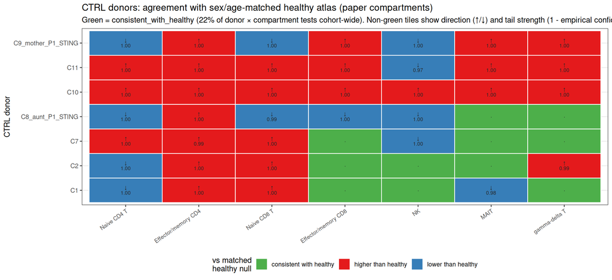

```r
ctrl_baseline_cols <- c(
  "consistent with healthy" = "#4DAF4A",
  "higher than healthy" = "#E41A1C",
  "lower than healthy" = "#377EB8"
)

ctrl_sample_order <- composition_ctrl_baseline_summary |>
  dplyr::arrange(dplyr::desc(.data$pct_consistent), .data$sample_id_observed) |>
  dplyr::pull(.data$sample_id_observed)

ctrl_heatmap_data <- composition_ctrl_baseline |>
  dplyr::mutate(
    sample_id_observed = factor(.data$sample_id_observed, levels = ctrl_sample_order),
    tile_label = dplyr::if_else(
      .data$agrees_with_healthy_baseline,
      "·",
      .data$tile_label
    )
  )

ggplot2::ggplot(
  ctrl_heatmap_data,
  ggplot2::aes(
    x = paper_compartment,
    y = sample_id_observed,
    fill = baseline_agreement
  )
) +
  ggplot2::geom_tile(color = "white", linewidth = 0.45) +
  ggplot2::geom_text(
    ggplot2::aes(label = tile_label),
    size = 2.5,
    lineheight = 0.85,
    color = "grey15"
  ) +
  ggplot2::scale_fill_manual(
    values = ctrl_baseline_cols,
    name = "vs matched\nhealthy null"
  ) +
  ggplot2::labs(
    title = "CTRL donors: agreement with sex/age-matched healthy atlas (paper compartments)",
    subtitle = paste0(
      "Green = consistent_with_healthy (",
      sprintf("%.0f", composition_ctrl_baseline_overall$pct_consistent),
      "% of donor × compartment tests cohort-wide). ",
      "Non-green tiles show direction (↑/↓) and tail strength (1 - empirical confidence)."
    ),
    x = NULL,
    y = "CTRL donor"
  ) +
  ggplot2::theme_bw() +
  ggplot2::theme(
    axis.text.x = ggplot2::element_text(angle = 35, hjust = 1, size = 8),
    axis.text.y = ggplot2::element_text(size = 9),
    legend.position = "bottom"
  )
```

Each panel below is one **CTRL donor × paper compartment**: grey density = healthy **`predict_res`** draws for that donor’s **`sex`** and **`age_decade`**; coloured vertical line = observed proportion. Line colour matches the heatmap (green = consistent, red/blue = tail call). Text at each line reports **`p_above_healthy`** = P(draw ≥ obs) and **`p_below_healthy`** = P(draw ≤ obs) (same tail convention as gene-level tests).

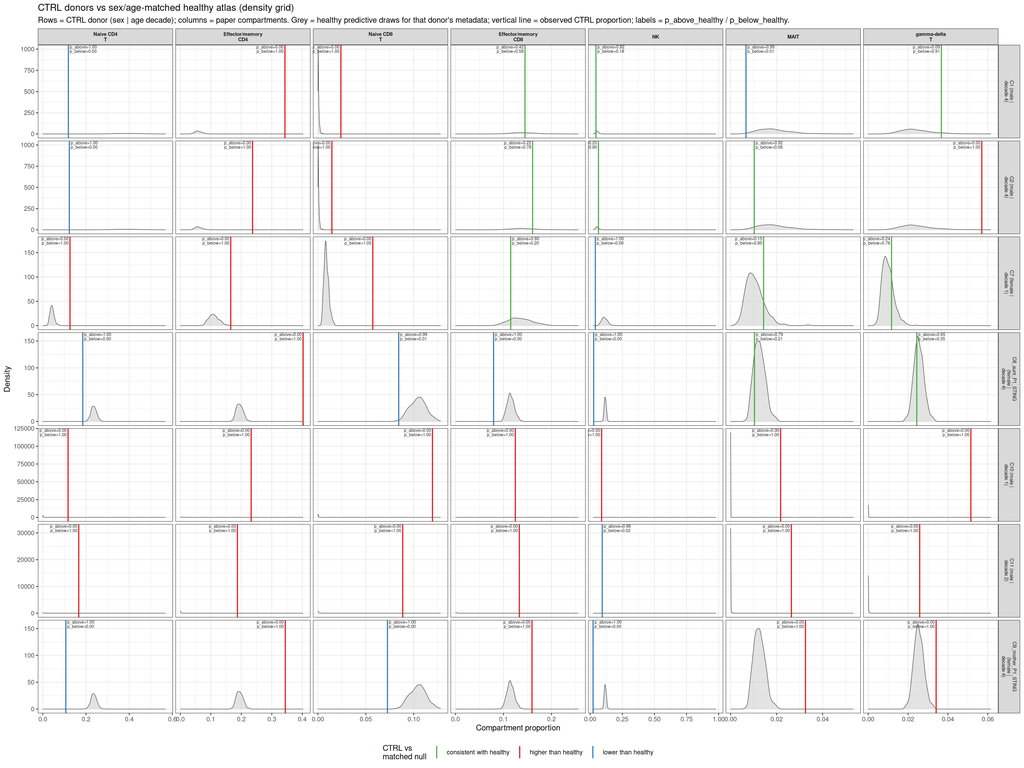

```r
compartment_levels <- paper_compartment_l3 |>
  dplyr::distinct(.data$paper_compartment) |>
  dplyr::pull(.data$paper_compartment)

if (!exists("baseline_compartment_draws")) {
  baseline_compartment_draws <- predict_res |>
    dplyr::inner_join(
      paper_compartment_l3 |>
        dplyr::distinct(.data$paper_compartment, .data$cell_type),
      by = "cell_type"
    ) |>
    dplyr::group_by(
      .data$paper_compartment,
      .data$age_decade,
      .data$sex,
      .data$.draw
    ) |>
    dplyr::summarise(
      compartment_proportion = sum(.data$proportion),
      .groups = "drop"
    )
}

ctrl_panel_meta <- composition_ctrl_baseline |>
  dplyr::distinct(
    .data$sample_id_observed,
    .data$sex,
    .data$age_decade,
    .data$paper_compartment
  ) |>
  dplyr::mutate(
    sample_panel = paste0(
      .data$sample_id_observed,
      " (",
      .data$sex,
      " | decade ",
      .data$age_decade,
      ")"
    )
  )

ctrl_panel_order <- composition_ctrl_baseline_summary |>
  dplyr::mutate(
    sample_panel = paste0(
      .data$sample_id_observed,
      " (",
      .data$sex,
      " | decade ",
      .data$age_decade,
      ")"
    )
  ) |>
  dplyr::arrange(dplyr::desc(.data$pct_consistent), .data$sample_id_observed)

ctrl_density_draws <- ctrl_panel_meta |>
  dplyr::inner_join(
    baseline_compartment_draws,
    by = c("sex", "age_decade", "paper_compartment")
  ) |>
  dplyr::mutate(
    sample_panel = factor(
      .data$sample_panel,
      levels = ctrl_panel_order$sample_panel
    ),
    paper_compartment = factor(.data$paper_compartment, levels = compartment_levels)
  ) |>
  dplyr::filter(
    is.finite(.data$compartment_proportion),
    .data$compartment_proportion >= 0
  )

ctrl_density_vlines <- composition_ctrl_baseline |>
  dplyr::mutate(
    sample_panel = paste0(
      .data$sample_id_observed,
      " (",
      .data$sex,
      " | decade ",
      .data$age_decade,
      ")"
    ),
    sample_panel = factor(
      .data$sample_panel,
      levels = ctrl_panel_order$sample_panel
    ),
    paper_compartment = factor(.data$paper_compartment, levels = compartment_levels),
    p_label = sprintf(
      "p_above=%.2f\np_below=%.2f",
      .data$p_above_healthy,
      .data$p_below_healthy
    )
  ) |>
  dplyr::filter(is.finite(.data$proportion_observed)) |>
  dplyr::left_join(
    ctrl_density_draws |>
      dplyr::group_by(.data$sample_panel, .data$paper_compartment) |>
      dplyr::summarise(
        x_mid = stats::median(.data$compartment_proportion, na.rm = TRUE),
        .groups = "drop"
      ),
    by = c("sample_panel", "paper_compartment")
  ) |>
  dplyr::mutate(
    text_hjust = dplyr::if_else(
      .data$proportion_observed > .data$x_mid,
      1.05,
      -0.05
    )
  )

ggplot2::ggplot(
  ctrl_density_draws,
  ggplot2::aes(x = compartment_proportion)
) +
  ggplot2::geom_density(
    fill = "grey80",
    color = "grey35",
    alpha = 0.55,
    linewidth = 0.35,
    na.rm = TRUE
  ) +
  ggplot2::geom_vline(
    data = ctrl_density_vlines,
    ggplot2::aes(
      xintercept = proportion_observed,
      color = baseline_agreement
    ),
    inherit.aes = FALSE,
    linewidth = 0.75
  ) +
  ggplot2::geom_text(
    data = ctrl_density_vlines,
    ggplot2::aes(
      x = proportion_observed,
      y = Inf,
      label = p_label,
      hjust = text_hjust
    ),
    inherit.aes = FALSE,
    vjust = 1.05,
    size = 2.1,
    lineheight = 0.85,
    color = "grey15"
  ) +
  ggplot2::facet_grid(
    sample_panel ~ paper_compartment,
    scales = "free",
    labeller = ggplot2::labeller(
      .cols = ggplot2::label_wrap_gen(10),
      .rows = ggplot2::label_wrap_gen(16)
    )
  ) +
  ggplot2::scale_color_manual(
    values = ctrl_baseline_cols,
    name = "CTRL vs\nmatched null"
  ) +
  ggplot2::scale_x_continuous(expand = ggplot2::expansion(mult = c(0.04, 0.06))) +
  ggplot2::labs(
    title = "CTRL donors vs sex/age-matched healthy atlas (density grid)",
    subtitle = paste(
      "Rows = CTRL donor (sex | age decade); columns = paper compartments.",
      "Grey = healthy predictive draws for that donor's metadata;",
      "vertical line = observed CTRL proportion;",
      "labels = p_above_healthy / p_below_healthy."
    ),
    x = "Compartment proportion",
    y = "Density"
  ) +
  ggplot2::theme_bw() +
  ggplot2::theme(
    legend.position = "bottom",
    strip.text.x = ggplot2::element_text(size = 7, face = "bold"),
    strip.text.y = ggplot2::element_text(size = 7),
    panel.spacing = grid::unit(0.25, "lines")
  )
```

### Healthy atlas comparison (plots)

Tail tests and visualizations below use **sex/age-matched** healthy **`predict_res`** draws (`composition_matched_reference`).

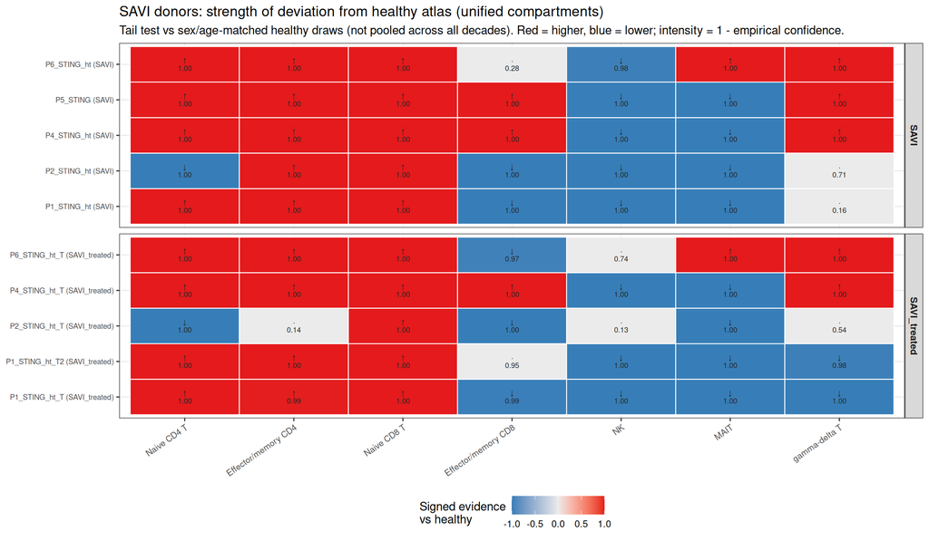

```r
# empirical_confidence = 2 * min(P(draw>=obs), P(draw<=obs)): near 0 = strong tail;
# near 1 = central. Signed score: direction x (1 - empirical_confidence).
heatmap_data <- composition_savi_vs_healthy |>
  dplyr::mutate(
    Category = factor(.data$Category, levels = c("SAVI", "SAVI_treated")),
    atlas_strength = 1 - .data$empirical_confidence,
    atlas_signed_score = dplyr::case_when(
      .data$direction_vs_healthy == "higher_than_healthy" ~ .data$atlas_strength,
      .data$direction_vs_healthy == "lower_than_healthy" ~ -.data$atlas_strength,
      TRUE ~ 0
    ),
    direction_short = dplyr::case_when(
      .data$direction_vs_healthy == "higher_than_healthy" ~ "↑",
      .data$direction_vs_healthy == "lower_than_healthy" ~ "↓",
      TRUE ~ "·"
    ),
    tile_label = sprintf(
      "%s\n%.2f",
      .data$direction_short,
      .data$atlas_strength
    ),
    sample_label = paste0(.data$sample_id_observed, " (", .data$Category, ")"),
    paper_compartment = factor(
      .data$paper_compartment,
      levels = unique(paper_compartment_l3$paper_compartment)
    )
  )

score_lim <- max(abs(heatmap_data$atlas_signed_score), na.rm = TRUE)
score_lim <- if (is.finite(score_lim) && score_lim > 0) score_lim else 1

ggplot2::ggplot(
  heatmap_data,
  ggplot2::aes(
    x = paper_compartment,
    y = sample_label,
    fill = atlas_signed_score
  )
) +
  ggplot2::geom_tile(color = "white", linewidth = 0.4) +
  ggplot2::geom_text(
    ggplot2::aes(label = tile_label),
    size = 2.4,
    lineheight = 0.85,
    color = "grey15"
  ) +
  ggplot2::scale_fill_gradient2(
    low = "#377EB8",
    mid = "grey92",
    high = "#E41A1C",
    midpoint = 0,
    limits = c(-score_lim, score_lim),
    oob = scales::squish,
    name = "Signed evidence\nvs healthy"
  ) +
  ggplot2::facet_grid(.data$Category ~ ., scales = "free_y", space = "free_y") +
  ggplot2::labs(
    title = "SAVI donors: strength of deviation from healthy atlas (unified compartments)",
    subtitle = paste(
      "Tail test vs sex/age-matched healthy draws (not pooled across all decades).",
      "Red = higher, blue = lower; intensity = 1 - empirical confidence."
    ),
    x = NULL,
    y = NULL
  ) +
  ggplot2::theme_bw() +
  ggplot2::theme(
    axis.text.x = ggplot2::element_text(angle = 35, hjust = 1, size = 8),
    axis.text.y = ggplot2::element_text(size = 7),
    strip.text = ggplot2::element_text(face = "bold"),
    legend.position = "bottom"
  )
```

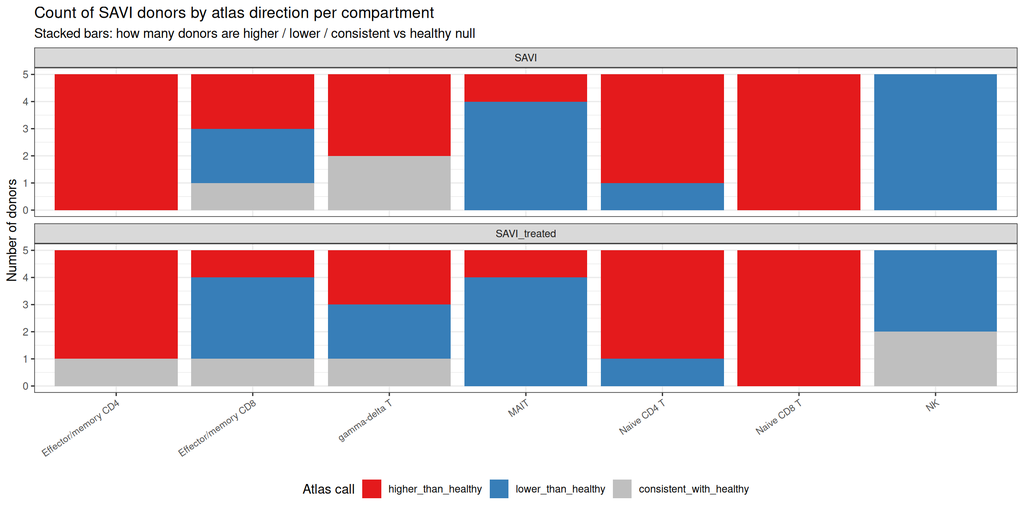

```r
direction_cols <- c(
  higher_than_healthy = "#E41A1C",
  lower_than_healthy = "#377EB8",
  consistent_with_healthy = "grey75"
)

count_long <- composition_savi_agreement_summary |>
  tidyr::pivot_longer(
    cols = c(n_higher, n_lower, n_consistent),
    names_to = "atlas_call",
    values_to = "n"
  ) |>
  dplyr::mutate(
    Category = factor(.data$Category, levels = c("SAVI", "SAVI_treated")),
    atlas_call = dplyr::recode(
      .data$atlas_call,
      n_higher = "higher_than_healthy",
      n_lower = "lower_than_healthy",
      n_consistent = "consistent_with_healthy"
    ),
    atlas_call = factor(.data$atlas_call, levels = names(direction_cols))
  )

ggplot2::ggplot(
  count_long,
  ggplot2::aes(x = paper_compartment, y = n, fill = atlas_call)
) +
  ggplot2::geom_col(position = "stack") +
  ggplot2::facet_wrap(~Category, ncol = 1) +
  ggplot2::scale_fill_manual(values = direction_cols, name = "Atlas call") +
  ggplot2::labs(
    title = "Count of SAVI donors by atlas direction per compartment",
    subtitle = "Stacked bars: how many donors are higher / lower / consistent vs healthy null",
    x = NULL,
    y = "Number of donors"
  ) +
  ggplot2::theme_bw() +
  ggplot2::theme(
    axis.text.x = ggplot2::element_text(angle = 35, hjust = 1, size = 8),
    legend.position = "bottom"
  )
```